# hw3

2023-10-10

## Problem 1

```r
library(tidyverse)
library(dplyr)
library(p8105.datasets)
data("instacart")

instacart =
  instacart |>
  as_tibble()

instacart |>
  count(aisle) |>
  arrange(desc(n))
```

```
## # A tibble: 134 × 2
##    aisle                              n
##    <chr>                          <int>
##  1 fresh vegetables              150609
##  2 fresh fruits                  150473
##  3 packaged vegetables fruits     78493
##  4 yogurt                         55240
##  5 packaged cheese                41699
##  6 water seltzer sparkling water  36617
##  7 milk                           32644
##  8 chips pretzels                 31269
##  9 soy lactosefree                26240
## 10 bread                          23635
## # ℹ 124 more rows
```

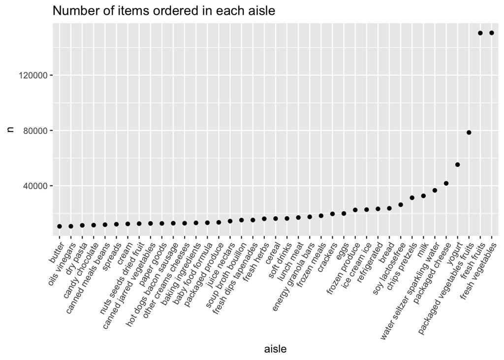

```r
instacart |>
  count(aisle) |>
  filter(n > 10000) |>
  mutate(aisle = fct_reorder(aisle, n)) |>
  ggplot(aes(x = aisle, y = n)) +
  geom_point() +
  labs(title = "Number of items ordered in each aisle") +
  theme(axis.text.x = element_text(angle = 60, hjust = 1))
```

```r
instacart |>
  filter(aisle %in% c("baking ingredients", "dog food care", "packaged vegetables fruits")) |>
  group_by(aisle) |>
  count(product_name) |>
  mutate(rank = min_rank(desc(n))) |>
  filter(rank < 4) |>
  arrange(desc(n)) |>
  knitr::kable()
```

| aisle | product_name | n | rank |
| --- | --- | --- | --- |
| packaged vegetables fruits | Organic Baby Spinach | 9784 | 1 |
| packaged vegetables fruits | Organic Raspberries | 5546 | 2 |
| packaged vegetables fruits | Organic Blueberries | 4966 | 3 |
| baking ingredients | Light Brown Sugar | 499 | 1 |
| baking ingredients | Pure Baking Soda | 387 | 2 |
| baking ingredients | Cane Sugar | 336 | 3 |
| dog food care | Snack Sticks Chicken & Rice Recipe Dog Treats | 30 | 1 |
| dog food care | Organix Chicken & Brown Rice Recipe | 28 | 2 |
| dog food care | Small Dog Biscuits | 26 | 3 |

```r
instacart |>
  filter(product_name %in% c("Pink Lady Apples", "Coffee Ice Cream")) |>
  group_by(product_name, order_dow) |>
  summarize(mean_hour = mean(order_hour_of_day)) |>
  pivot_wider(
    names_from = order_dow,
    values_from = mean_hour) |>
  knitr::kable(digits = 2)
```

| product_name | 0 | 1 | 2 | 3 | 4 | 5 | 6 |
| --- | --- | --- | --- | --- | --- | --- | --- |
| Coffee Ice Cream | 13.77 | 14.32 | 15.38 | 15.32 | 15.22 | 12.26 | 13.83 |
| Pink Lady Apples | 13.44 | 11.36 | 11.70 | 14.25 | 11.55 | 12.78 | 11.94 |

## Problem 2

```r
data("brfss_smart2010")

## data cleaning

  brfss_smart2010 =
  brfss_smart2010 |>
  janitor::clean_names() |>
  filter(
    topic == "Overall Health",
    response %in% c("Excellent","Very good", "Good", "Fair", "Poor")) |>
  mutate(
    response =
      fct_relevel(response, c("Poor", "Fair", "Good","Very good","Excellent" ))
  )
  brfss_smart2010
```

```
## # A tibble: 10,625 × 23
##     year locationabbr locationdesc     class topic question response sample_size
##    <int> <chr>        <chr>            <chr> <chr> <chr>    <fct>          <int>
##  1  2010 AL           AL - Jefferson … Heal… Over… How is … Excelle…          94
##  2  2010 AL           AL - Jefferson … Heal… Over… How is … Very go…         148
##  3  2010 AL           AL - Jefferson … Heal… Over… How is … Good             208
##  4  2010 AL           AL - Jefferson … Heal… Over… How is … Fair             107
##  5  2010 AL           AL - Jefferson … Heal… Over… How is … Poor              45
##  6  2010 AL           AL - Mobile Cou… Heal… Over… How is … Excelle…          91
##  7  2010 AL           AL - Mobile Cou… Heal… Over… How is … Very go…         177
##  8  2010 AL           AL - Mobile Cou… Heal… Over… How is … Good             224
##  9  2010 AL           AL - Mobile Cou… Heal… Over… How is … Fair             120
## 10  2010 AL           AL - Mobile Cou… Heal… Over… How is … Poor              66
## # ℹ 10,615 more rows
## # ℹ 15 more variables: data_value <dbl>, confidence_limit_low <dbl>,
## #   confidence_limit_high <dbl>, display_order <int>, data_value_unit <chr>,
## #   data_value_type <chr>, data_value_footnote_symbol <chr>,
## #   data_value_footnote <chr>, data_source <chr>, class_id <chr>,
## #   topic_id <chr>, location_id <chr>, question_id <chr>, respid <chr>,
## #   geo_location <chr>
```

## in 2002, which states were observed at 7 or more locations? What about in 2010?

In 2002, 6 states were observed at 7 or more locations. In 2010, 14 states were observed in 7 or more locations.

```r
states_obs <- brfss_smart2010 |>
  filter(year %in% c(2002, 2010)) |>
  select(year, locationabbr, locationdesc) |>
  distinct() |>
   group_by(year, locationabbr) |>
  summarize(n = n()) |>
  filter(n >= 7) |>
  arrange(year, desc(n))
```

## Construct a dataset that is limited to Excellent responses, and contains, year, state, and a variable that averages the data_value across locations within a state.

```r
excellent_data <- brfss_smart2010 |>
  filter(response %in% c("Excellent")) |>
  select(year, locationabbr, data_value) |>
  group_by(locationabbr, year) |>
  mutate(
    avg_data_value = mean(data_value)) |>
  select(year, locationabbr, avg_data_value) |>
  distinct()
```

## spaghetti plot

The plot shows the average data value for each state from the years 2002-2010. Overall, the data has a lot of overlap, but has some outlier values. For example, there appears to be a low average data value score in 2005 for the state of West Virginia.

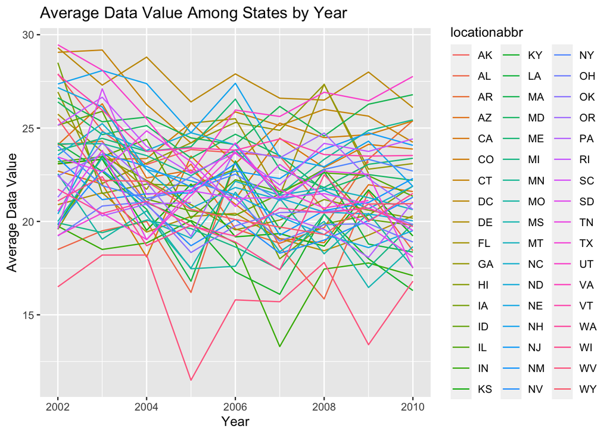

```r
excellent_data |>
  ggplot(aes(x = year, y = avg_data_value)) +
  geom_line(aes(group = locationabbr, color = locationabbr)) +
  labs(
    title = "Average Data Value Among States by Year",
    x = "Year",
    y = "Average Data Value")
```

## make a two-panel plot showing, for the years 2006, and 2010, distribution of data_value for responses (“Poor” to “Excellent”) among locations in NY State

Overall, there is more variability in the 2010 resonses compared to the 2006 responses. The “very good” response appears to have improved the most over the course of four years.

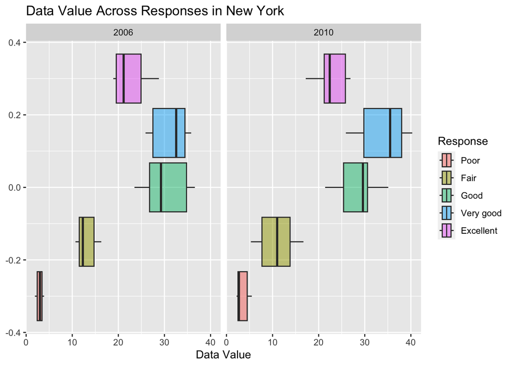

```r
brfss_smart2010 |>
  select(year, data_value, locationabbr, locationdesc, response) |>
  filter(
    year == 2006 | year == 2010,
    locationabbr == "NY") |>
  ggplot(aes(x = data_value, fill = response)) +
  geom_boxplot(aes(fill = response), alpha = .5) +

  labs(
    title = "Data Value Across Responses in New York",
    x = "Data Value",
    fill = "Response") +
  facet_grid(. ~ year)
```

## Problem 3

```r
## load, tidy, merge, and otherwise organize the data sets.

covar_data <- read.csv("nhanes_covar.csv", skip = 4)  #, sep = '\t', skip = 4, col.names = c("seqn", "SEQN"))
accel_data <- read.csv("nhanes_accel.csv")

covar_data_clean = covar_data |>
  filter(age >= 21) |>
  drop_na() |>
  mutate(
    sex =
      case_match(
        sex,
        1 ~ "male",
        2 ~ "female"
      ),
    sex = as.factor(sex),
    education =
      case_match(
        education,
        1 ~ "less than high school",
        2 ~ "high school equivalent",
        3 ~ "more than high school"
      ),
    education = as.factor(education)
  )

merged_data =
  left_join(covar_data_clean, accel_data, by = "SEQN")
```

## Produce a reader-friendly table for the number of men and women in each education category, and create a visualization of the age distributions for men and women in each education category. Comment on these items.

Between 20-40 years old, most individuals had more than a high school education. Between 40-60 years old, the education level is more variable between high school equivalent, less than high school, and more than high school. Ages 60 and above, less individuals have more than a high school education compared to the other age groups.

```r
merged_data |>
  drop_na() |>
  group_by(sex, education) |>
  summarize(count = n()) |>
  knitr::kable(digits = 1)
```

[output not shown]

| sex | education | count |
| --- | --- | --- |
| female | high school equivalent | 23 |
| female | less than high school | 28 |
| female | more than high school | 59 |
| male | high school equivalent | 35 |
| male | less than high school | 27 |
| male | more than high school | 56 |

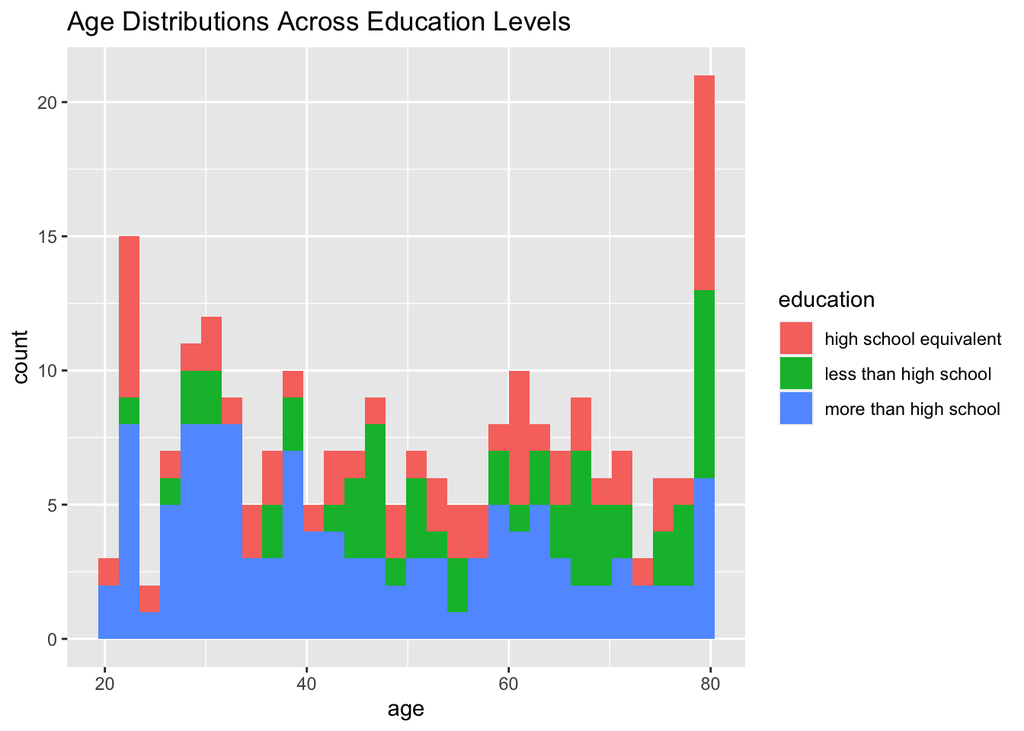

```r
merged_data |>
  drop_na() |>
  ggplot(aes(x = age, fill = education)) +
  labs(
    title = "Age Distributions Across Education Levels") +
  geom_histogram()
```

## Using your tidied dataset, aggregate across minutes to create a total activity variable for each participant. Plot these total activities

Overall across the plots, it does not seem that education level impacts total activity. The more than high school panel has the most data points, but they are sporadic like the other two education level panels. Across sex, women appear to have slightly more total activity than men in the high school equivalent and more than high school panels.

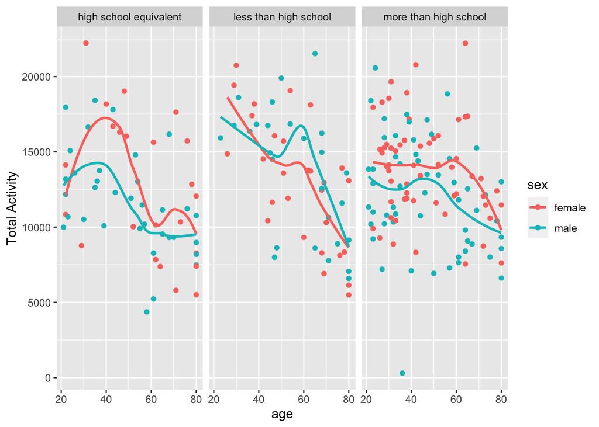

```r
merged_data |>
  mutate(
    total_activity = rowSums(across(min1:min1440), na.rm = TRUE)) |>
    ggplot(aes(x = age, y = total_activity, color = sex)) + geom_point() + geom_smooth(se = FALSE) + labs(y = "Total Activity") + facet_grid(.~education)
```

## Make a three-panel plot that shows the 24-hour activity time courses for each education level and use color to indicate sex.

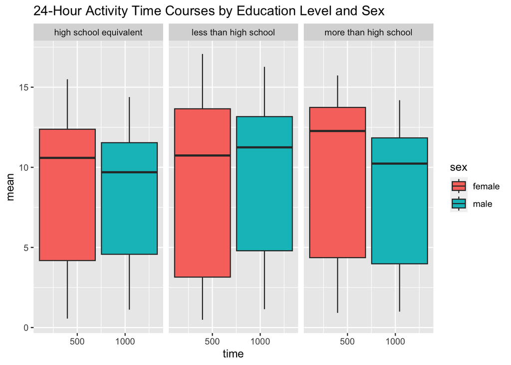

```r
day_activity = merged_data |>
  group_by(education, sex) |>
  summarize(across(starts_with("min"), ~ mean(.), .names = "mean_{.col}"), .groups = "drop") |>
  pivot_longer(cols = starts_with("mean_"), names_to = "time", values_to = "mean") |>
  mutate(
    time = substring(time, 9),
    time = as.numeric(time))
ggplot(day_activity, aes(x = time, y = mean, fill = sex)) + geom_boxplot() +  facet_grid(.~ education) +
  labs(title = "24-Hour Activity Time Courses by Education Level and Sex")
```